# Preparación de los datos

# Estudiante

- Merian Herrera Fuentes
- meryann68@gmail.com
- 207180364

```r
library(GGally)
```

```r
library(ggplot2)
```

# Breve introducción a ggpairs

`ggpairs()` es una función de la librería GGally que permite crear matrices de gráficos y es realmente útil en la etapa de análisis y exploración de los datos. Pueden encontrar más información sobre `ggpairs()` y GGally en el siguiente enlace https://ggobi.github.io/ggally/#ggally

El siguiente ejemplo muestra el gráfico de las correlaciones y densidades de algunos atributos del dataset de ventas de casas.

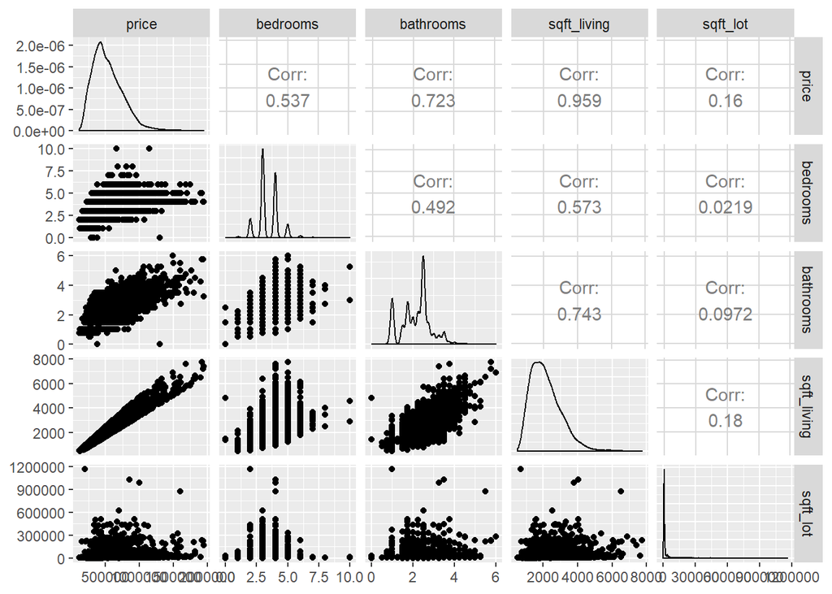

```r
casas <- read.csv('kc_house_data.csv', header = T, na.strings = '?')
ggpairs(casas, columns = 3:7)
```

# Limpieza y transformación de los datos

A continuación utilizando el dataset de venta de casas veremos algunas funcionalidades de R para la transformación de datos.

### Detección de valores faltantes y transformaciones

La función `is.na` nos permite detectar los valores faltantes en un dataset.

El siguiente código muestra el número de elementos faltantes en todo un dataset

```r
sum(is.na(casas))
```

```
## [1] 0
```

También podemos buscar valores faltantes en columnas especificas

```r
sum(is.na(casas$price))
```

```
## [1] 0
```

R posee funciones para modificar dataframes las cuales podemos aprovechar para el tratamiento de valores faltantes y transformaciones

Podemos asignar valores nuevos a toda una columna.

`dataframe$columna <- 0`

`dataframe$columna <- funcion(dataframe$columna)`

O podemos hacerlo solo en los campos faltantes.

`dataframe$columna[is.na(dataframe$columna)] <- 0`

`dataframe$columna[is.na(dataframe$columna)] <- funcion(dataframe$columna)`

# Ejercicios sobre transformaciones

### 1. Correción de valores inconsistentes

```r
casas$bathrooms[1:10]
```

```
##  [1] 2.25 1.00 4.50 1.50 1.00 1.75 2.00 3.00 2.00 1.75
```

Como podemos observar la columna bathrooms posee valores inconsistentes ya que no tiene sentido que una casa tenga 2.25 baños.

Modifique la columna bathrooms para que solo posea valores enteros

```r
casas$bathrooms <- ceiling(casas$bathrooms)

casas$bathrooms[1:10]
```

```
##  [1] 3 1 5 2 1 2 2 3 2 2
```

Se decide usar la funcion `cealing()` para redondear los valores de la variable “bathrooms” ya que la misma aplica un redondeo hacia el numero mayor. Esto porque el dataset se trata sobre datos para la venta de casas, en el negocio de los bienes inmuebles muchas veces escuchamos que las casas tienen 2.5 baños, para referirse a que la casa tiene dos baños completos (Sanitario y ducha) y uno que es solo sanitario, por lo tanto podemos asumir que la casa en realidad tiene 3 baños. Ademas, para efectos de vender y promocionar las casas es mas llamativa una casa que tiene 3 baños a una que tiene 2 baños.

### 2. Llevar los datos a distribución normal.

Modifique la columna price del dataset de precios de casas para que siga una distribución normal. Pista: utilice la función `log10`

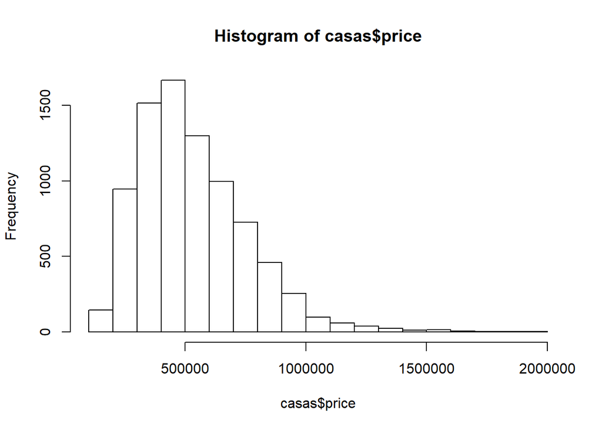

```r
# Precios antes de la modificación
hist(casas$price)
```

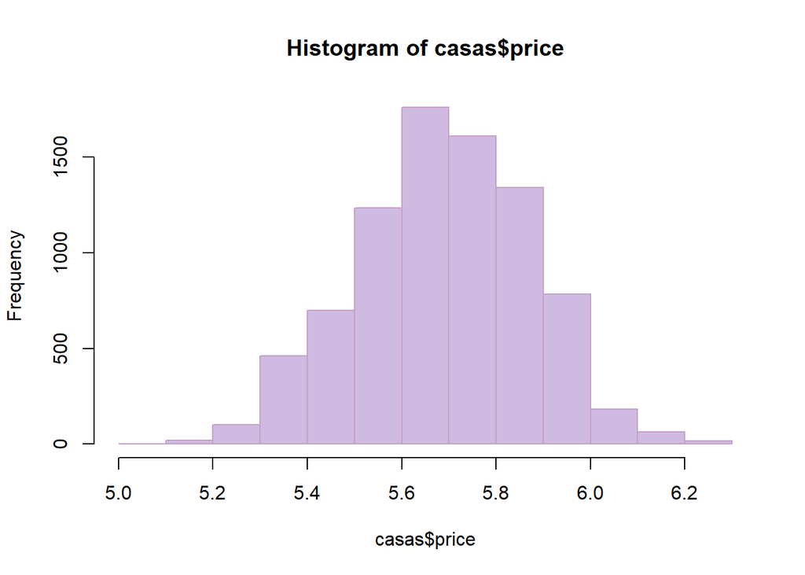

```r
# Escriba su codigo aqui
casas$price <- log10(casas$price)
# Precios normalmente distribuidos
hist(casas$price, col="#cfbae1",border="#c59fc9")
```

Note que ahora los precios ya no se agrupan a la izquierda.

### 3. Imputar datos faltantes

Reemplace los valores faltantes de la columna sqft_living con la mediana de los valores de esa columna. Pista use la función `median`.

Nota: este dataset no posee valores faltantes pero para efectos del ejercicio esto no nos afecta ya que el código sería igual.

```r
media_sqft_living = median(casas$sqft_living)
media_sqft_living
```

```
## [1] 2010
```

```r
casas$sqft_living[is.na(casas$sqft_living)] <- media_sqft_living
head(casas$sqft_living, 100)
```

```
##   [1] 2570  770 5420 1060 1430 1370 1810 2950 1890 1620 1070 1520 2570 2320
##  [15] 1190 2330 2360 2620 2570 3595 1280  990 1980 3250 1850 1260 2519 1660
##  [29] 1000 4770 1260 2750 3430 1760 1410 3450 1680 1580 3300 1980 1210 1670
##  [43] 3140 2030 2310  880 2400 1450 2100 2910 2100 2070 1060 2010 2030 3670
##  [57] 1250 1780 3400 1910 2020 1580 1340 2680 1370 1340 3880 2590 1970 1350
##  [71] 2440 3130 4090 1900 2230 1060 1970 2150 1910 1350  860 2440  900 2300
##  [85] 1550 2240 1720 3900 2760 2330 2280 1000 3760 1970 3830  830  720 1510
##  [99] 1400 1230
```

### 4. Escalado

Un proceso común en esta etapa es escalar los atributos para que los valores queden en el rango de 0-1.

La siguiente función realiza el escalado de valores

```r
feature_scaling <- function(x) {
  x_escalado <- ((x - min(x)) / (max(x) - min(x)))
  return(x_escalado)
}
```

1. Utilice la función `feature_scaling` para escalar los valores de la columna sqft_lot
2. Compare el resultado con la función `scale()`

```r
head(casas$sqft_lot, 100)
```

```
##   [1]   7242  10000 101930   9711  19901   9680   4850   5000  14040   4980
##  [11]   9643   6380   7173   3980   1265   5000   6000   7553   5520   5639
##  [21]   9656   8528   8550  14342   9976   8400   8690   6000  12070  50094
##  [31]   5612   7807  35102   7300   5060  39683   8712   5000  10250   3478
##  [41]  33919   4005  28037  12342   9624   6780   6474   9132   4400  10204
##  [51]   8201   4310   7875   2287   8517 315374   8200   9660  16603   7280
##  [61]  38332   7000   7250   9750   8336   7912  35003   8190   5400   8220
##  [71]   9600  13412  12850   8744  10026  10228   6480   4084  66211 155073
##  [81]  11725   4587   9600   3404   7579  12032   6270  14864   6440  19436
##  [91]  15347  10200  28040   4740 221284   6000   5120  36224   3538  10170
```

```r
with_feature_scaling <- feature_scaling(casas$sqft_lot)
head(with_feature_scaling, 100)
```

```
##   [1] 0.0057735550 0.0081424132 0.0871014899 0.0078941899 0.0166464252
##   [6] 0.0078675638 0.0037190558 0.0038478915 0.0116123868 0.0038307134
##  [11] 0.0078357844 0.0050331795 0.0057142906 0.0029718090 0.0006398837
##  [16] 0.0038478915 0.0047067958 0.0060406743 0.0042945217 0.0043967314
##  [21] 0.0078469501 0.0068781060 0.0068970019 0.0118717759 0.0081217995
##  [26] 0.0067681663 0.0070172485 0.0047067958 0.0099203452 0.0425793241
##  [31] 0.0043735409 0.0062588360 0.0297026301 0.0058233715 0.0038994257
##  [36] 0.0336372710 0.0070361444 0.0038478915 0.0083571393 0.0025406391
##  [41] 0.0286865463 0.0029932817 0.0236344709 0.0101539672 0.0078194652
##  [46] 0.0053767412 0.0051139165 0.0073968842 0.0033325489 0.0083176297
##  [51] 0.0065972443 0.0032552475 0.0063172415 0.0015176840 0.0068686581
##  [56] 0.2704294694 0.0065963854 0.0078503857 0.0138137586 0.0058061934
##  [61] 0.0324768912 0.0055657002 0.0057804263 0.0079276871 0.0067131964
##  [66] 0.0063490209 0.0296175986 0.0065877963 0.0041914532 0.0066135635
##  [71] 0.0077988515 0.0110729948 0.0105902906 0.0070636294 0.0081647447
##  [76] 0.0083382434 0.0051190699 0.0030611351 0.0564222855 0.1327462436
##  [81] 0.0096240232 0.0034931640 0.0077988515 0.0024770801 0.0060630058
##  [86] 0.0098877068 0.0049387000 0.0123201240 0.0050847137 0.0162470346
##  [91] 0.0127349748 0.0083141941 0.0236370476 0.0036245763 0.1896151593
##  [96] 0.0047067958 0.0039509600 0.0306663208 0.0025921733 0.0082884270
```

```r
with_scale <- scale(casas$sqft_lot)
head(with_scale, 100)
```

```
##               [,1]
##   [1,] -0.22998116
##   [2,] -0.16880564
##   [3,]  1.87030444
##   [4,] -0.17521598
##   [5,]  0.05080960
##   [6,] -0.17590360
##   [7,] -0.28303839
##   [8,] -0.27971122
##   [9,] -0.07919393
##  [10,] -0.28015485
##  [11,] -0.17672430
##  [12,] -0.24910128
##  [13,] -0.23151166
##  [14,] -0.30233596
```

[output cut: 86 more lines]

### 5. Normalización con la función z-score

Otra función utilizada para transformar atributos se llama z-score y consiste en restar la media de los datos y dividir por la desviación estandar.

Escriba la función z_score y utilicela sobre la columna bathrooms.

Pista: utilice las funciones `mean`, `sd`

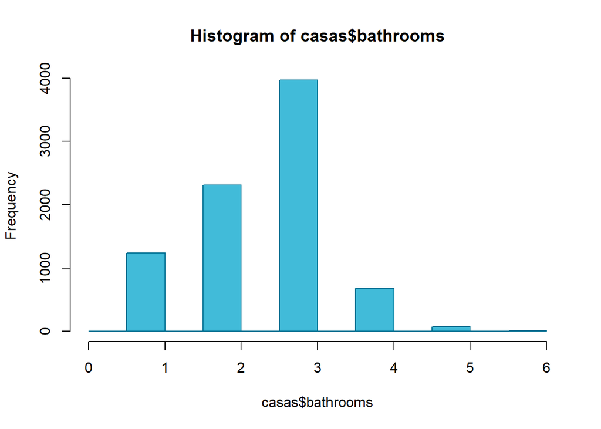

```r
# Datos antes de la transformación
hist(casas$bathrooms, col="#41bbd9",border="#006e90")
```

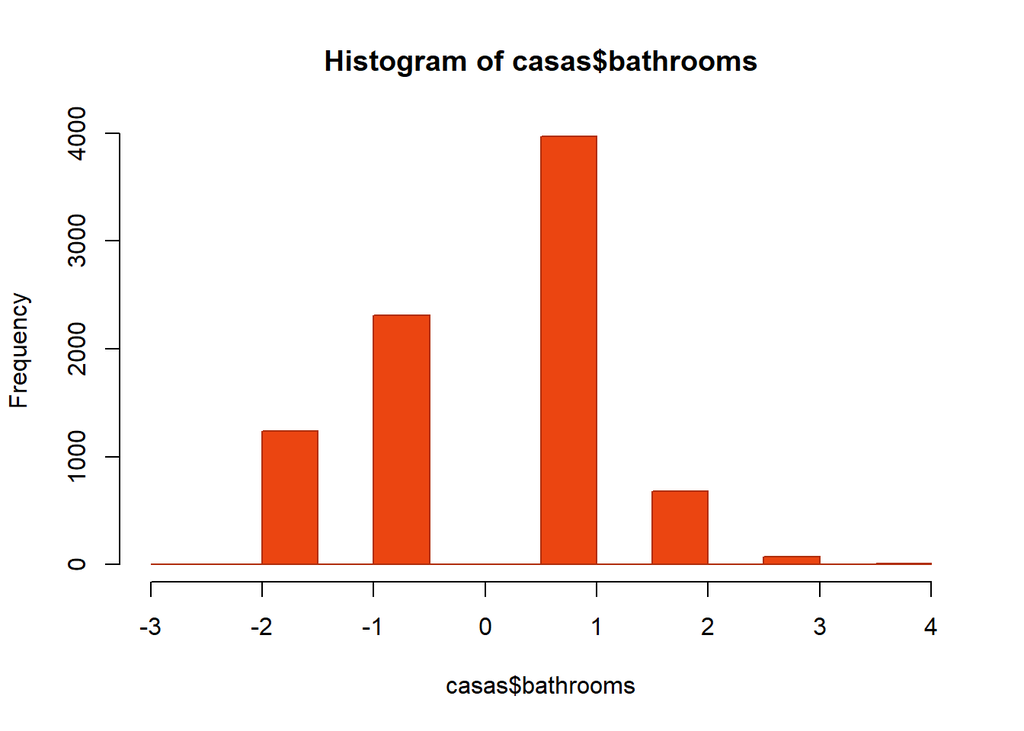

```r
# Escriba su código aqui
z_score <- function(values) {
  score <- (values - mean(values)) / (sd(values))
  return(score)
}

casas$bathrooms <- z_score(casas$bathrooms)
# Después de la transformación
hist(casas$bathrooms, col="#eb4511",border="#b02e0c")
```

Note que ahora la media de los datos se acerca a 0